# ReCell

```python
import numpy as np
import pandas as pd
import matplotlib.pyplot as plt
import seaborn as sns
sns.set()
from sklearn.model_selection import train_test_split
from sklearn.linear_model import LinearRegression
from sklearn.metrics import mean_absolute_error, mean_squared_error, r2_score
import statsmodels.api as sm
from statsmodels.stats.outliers_influence import variance_inflation_factor
```

Observation: Importing the necessary libraries and data

```python
data = pd.read_csv("C:\\Users\\bilal\\Documents\\used_device_data.csv")
```

```python
data.shape
```

```
(3454, 15)
```

Observation: Getting the shape of the dataset

```python
data.sample(n=10, random_state=1)
```

|  | brand_name | os | screen_size | 4g | 5g | main_camera_mp | selfie_camera_mp | int_memory | ram | battery | weight | release_year | days_used | normalized_used_price | normalized_new_price |
| --- | --- | --- | --- | --- | --- | --- | --- | --- | --- | --- | --- | --- | --- | --- | --- |
| 866 | Others | Android | 15.24 | no | no | 8.00 | 2.0 | 16.0 | 4.00 | 3000.0 | 206.0 | 2014 | 632 | 4.038832 | 5.190788 |
| 957 | Celkon | Android | 10.16 | no | no | 3.15 | 0.3 | 512.0 | 0.25 | 1400.0 | 140.0 | 2013 | 637 | 2.800325 | 3.884652 |
| 280 | Infinix | Android | 15.39 | yes | no | NaN | 8.0 | 32.0 | 2.00 | 5000.0 | 185.0 | 2020 | 329 | 4.370713 | 4.487287 |
| 2150 | Oppo | Android | 12.83 | yes | no | 13.00 | 16.0 | 64.0 | 4.00 | 3200.0 | 148.0 | 2017 | 648 | 4.677863 | 5.639422 |
| 93 | LG | Android | 15.29 | yes | no | 13.00 | 5.0 | 32.0 | 3.00 | 3500.0 | 179.0 | 2019 | 216 | 4.517650 | 5.300415 |
| 1040 | Gionee | Android | 12.83 | yes | no | 13.00 | 8.0 | 32.0 | 4.00 | 3150.0 | 166.0 | 2016 | 970 | 4.645640 | 5.634325 |
| 3170 | ZTE | Others | 10.16 | no | no | 3.15 | 5.0 | 16.0 | 4.00 | 1400.0 | 125.0 | 2014 | 1007 | 3.764451 | 4.244344 |
| 2742 | Sony | Android | 12.70 | yes | no | 20.70 | 2.0 | 16.0 | 4.00 | 3000.0 | 170.0 | 2013 | 1060 | 4.422809 | 5.799820 |
| 102 | Meizu | Android | 15.29 | yes | no | NaN | 20.0 | 128.0 | 6.00 | 3600.0 | 165.0 | 2019 | 332 | 4.959412 | 6.040659 |
| 1195 | HTC | Android | 10.29 | no | no | 8.00 | 2.0 | 32.0 | 4.00 | 2000.0 | 146.0 | 2015 | 892 | 4.227855 | 4.879007 |

Observation: Viewing a sample of the data

```python
df = data.copy()
```

```python
Observation: Creating a copy of the data to avoid any changes to original data
```

```python
df.info()
```

```
<class 'pandas.core.frame.DataFrame'>
RangeIndex: 3454 entries, 0 to 3453
Data columns (total 15 columns):
 #   Column                 Non-Null Count  Dtype
---  ------                 --------------  -----
 0   brand_name             3454 non-null   object
 1   os                     3454 non-null   object
 2   screen_size            3454 non-null   float64
 3   4g                     3454 non-null   object
 4   5g                     3454 non-null   object
 5   main_camera_mp         3275 non-null   float64
 6   selfie_camera_mp       3452 non-null   float64
 7   int_memory             3450 non-null   float64
 8   ram                    3450 non-null   float64
 9   battery                3448 non-null   float64
 10  weight                 3447 non-null   float64
 11  release_year           3454 non-null   int64
 12  days_used              3454 non-null   int64
 13  normalized_used_price  3454 non-null   float64
 14  normalized_new_price   3454 non-null   float64
dtypes: float64(9), int64(2), object(4)
memory usage: 404.9+ KB
```

Observation: checking the column names and datatypes

```python
data.duplicated().sum()
```

```
0
```

Observation: Checking for duplicate values

```python
data.isna().sum()
```

```
brand_name                 0
os                         0
screen_size                0
4g                         0
5g                         0
main_camera_mp           179
selfie_camera_mp           2
int_memory                 4
ram                        4
battery                    6
weight                     7
release_year               0
days_used                  0
normalized_used_price      0
normalized_new_price       0
dtype: int64
```

Observation: Checking for missing values in the data

```python
data.describe()
```

|  | screen_size | main_camera_mp | selfie_camera_mp | int_memory | ram | battery | weight | release_year | days_used | normalized_used_price | normalized_new_price |
| --- | --- | --- | --- | --- | --- | --- | --- | --- | --- | --- | --- |
| count | 3454.000000 | 3275.000000 | 3452.000000 | 3450.000000 | 3450.000000 | 3448.000000 | 3447.000000 | 3454.000000 | 3454.000000 | 3454.000000 | 3454.000000 |
| mean | 13.713115 | 9.460208 | 6.554229 | 54.573099 | 4.036122 | 3133.402697 | 182.751871 | 2015.965258 | 674.869716 | 4.364712 | 5.233107 |
| std | 3.805280 | 4.815461 | 6.970372 | 84.972371 | 1.365105 | 1299.682844 | 88.413228 | 2.298455 | 248.580166 | 0.588914 | 0.683637 |
| min | 5.080000 | 0.080000 | 0.000000 | 0.010000 | 0.020000 | 500.000000 | 69.000000 | 2013.000000 | 91.000000 | 1.536867 | 2.901422 |
| 25% | 12.700000 | 5.000000 | 2.000000 | 16.000000 | 4.000000 | 2100.000000 | 142.000000 | 2014.000000 | 533.500000 | 4.033931 | 4.790342 |
| 50% | 12.830000 | 8.000000 | 5.000000 | 32.000000 | 4.000000 | 3000.000000 | 160.000000 | 2015.500000 | 690.500000 | 4.405133 | 5.245892 |
| 75% | 15.340000 | 13.000000 | 8.000000 | 64.000000 | 4.000000 | 4000.000000 | 185.000000 | 2018.000000 | 868.750000 | 4.755700 | 5.673718 |
| max | 30.710000 | 48.000000 | 32.000000 | 1024.000000 | 12.000000 | 9720.000000 | 855.000000 | 2020.000000 | 1094.000000 | 6.619433 | 7.847841 |

Observation: The statistical summary of the data

```python
def histogram_boxplot(data, feature, figsize=(12, 7), kde=False, bins=None):
    """
    Boxplot and histogram combined

    data: dataframe
    feature: dataframe column
    figsize: size of figure (default (12,7))
    kde: whether to the show density curve (default False)
    bins: number of bins for histogram (default None)
    """
    f2, (ax_box2, ax_hist2) = plt.subplots(
        nrows=2,
        sharex=True,
        gridspec_kw={"height_ratios": (0.25, 0.75)},
        figsize=figsize,
    )
    sns.boxplot(
        data=data, x=feature, ax=ax_box2, showmeans=True, color="violet"
    )
    sns.histplot(
        data=data, x=feature, kde=kde, ax=ax_hist2, bins=bins, palette="winter"
    ) if bins else sns.histplot(
        data=data, x=feature, kde=kde, ax=ax_hist2
    )
    ax_hist2.axvline(
        data[feature].mean(), color="green", linestyle="--"
    )
    ax_hist2.axvline(
        data[feature].median(), color="black", linestyle="-"
    )
```

```python
def labeled_barplot(data, feature, perc=False, n=None):
    """
    Barplot with percentage at the top

    data: dataframe
    feature: dataframe column
    perc: whether to display percentages instead of count (default is False)
    n: displays the top n category levels (default is None, i.e., display all levels)
    """

    total = len(data[feature])
    count = data[feature].nunique()
    if n is None:
        plt.figure(figsize=(count + 1, 5))
    else:
        plt.figure(figsize=(n + 1, 5))

    plt.xticks(rotation=90, fontsize=15)
    ax = sns.countplot(
        data=data,
        x=feature,
        palette="Paired",
        order=data[feature].value_counts().index[:n].sort_values(),
    )

    for p in ax.patches:
        if perc == True:
            label = "{:.1f}%".format(
                100 * p.get_height() / total
            )
        else:
            label = p.get_height()

        x = p.get_x() + p.get_width() / 2
        y = p.get_height()

        ax.annotate(
            label,
            (x, y),
            ha="center",
            va="center",
            size=12,
            xytext=(0, 5),
            textcoords="offset points",
        )

    plt.show()
```

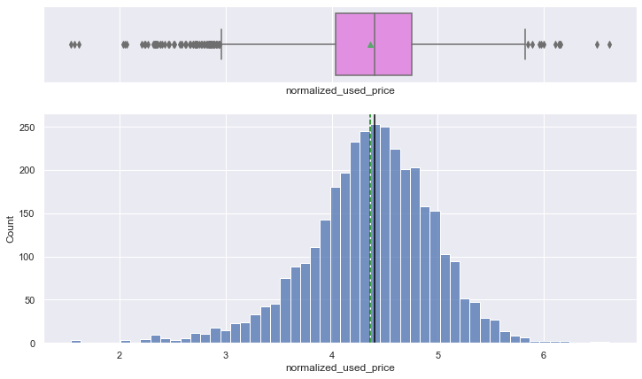

```python
histogram_boxplot(df, "normalized_used_price")
```

Observation: Histogram and Boxplot for normalized_used_price

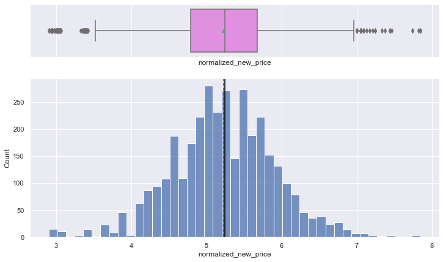

```python
histogram_boxplot(df, "normalized_new_price")
```

Observation: Histogram and Boxplot for normalized_new_price

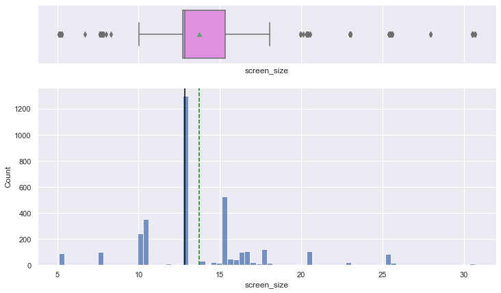

```python
histogram_boxplot(df, "screen_size")
```

Observation: Histogram and Boxplot for screen_size

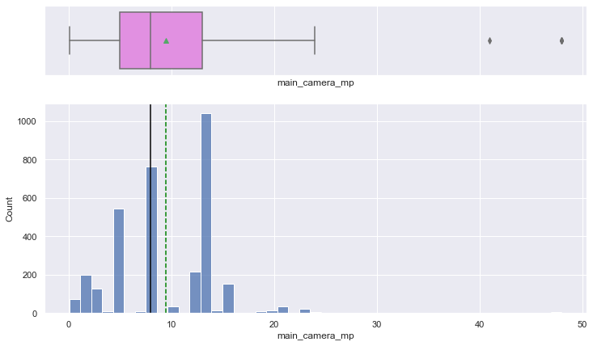

```python
histogram_boxplot(df, "main_camera_mp")
```

Observation: Histogram and Boxplot for main_camera_mp

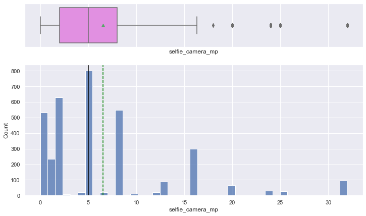

```python
histogram_boxplot(df, "selfie_camera_mp")
```

Observation: Histogram and Boxplot for selfie_camera_mp

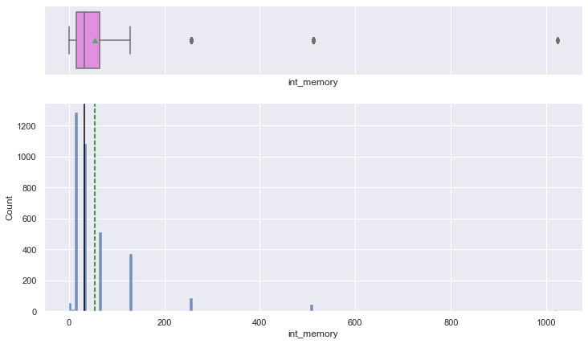

```python
histogram_boxplot(df, "int_memory")
```

Observation: Histogram and Boxplot for int_memory

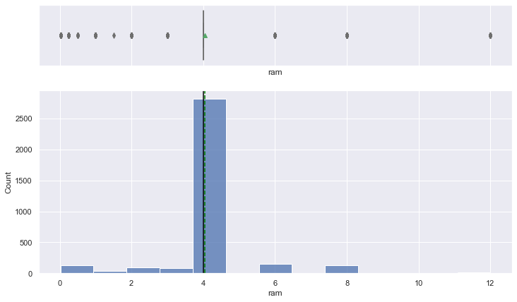

```python
histogram_boxplot(df, "ram")
```

Observation: Histogram and Boxplot for ram

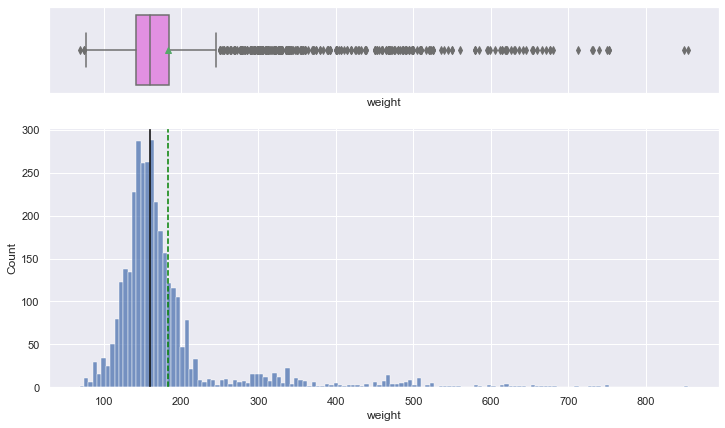

```python
histogram_boxplot(df, "weight")
```

Observation: Histogram and Boxplot for weight

```python
df["weight_log"] = np.log(df["weight"])
```

Observation: Distribution of weight closer to normal

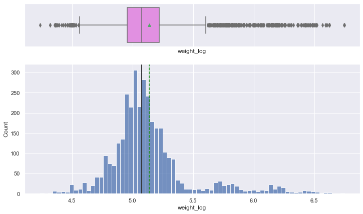

```python
histogram_boxplot(df, "weight_log")
```

Observation: Histogram and Boxplot for weight_log

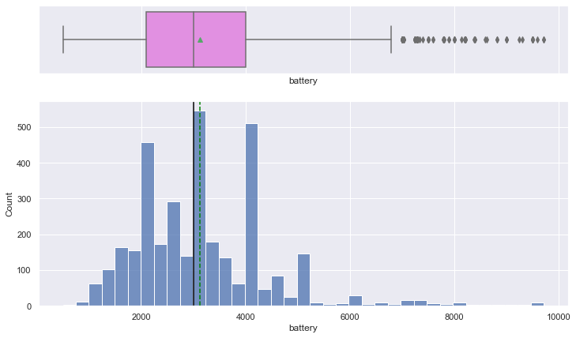

```python
histogram_boxplot(df, "battery")
```

Observation: Histogram and Boxplot for battery

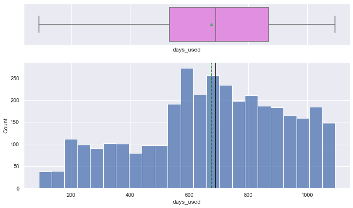

```python
histogram_boxplot(df, "days_used")
```

Observation: Histogram and Boxplot for days_used

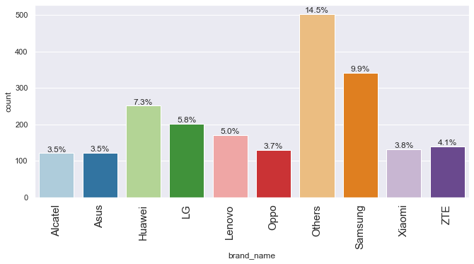

```python
labeled_barplot(df, "brand_name", perc=True, n=10)
```

Observation: Barplot for brand_name

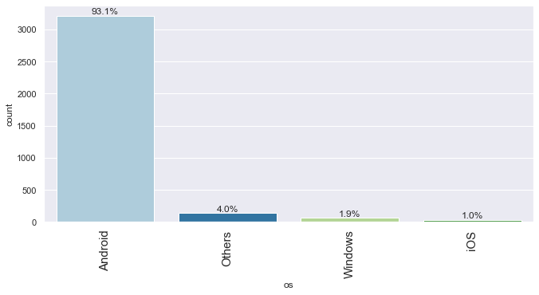

```python
labeled_barplot(df, "os", perc=True, n=10)
```

Observation: Barplot for os

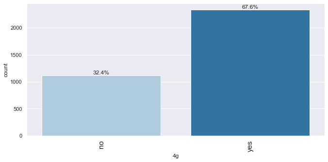

```python
labeled_barplot(df, "4g", perc=True, n=10)
```

Observation: Barplot for 4g

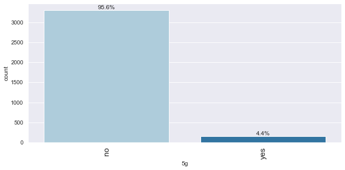

```python
labeled_barplot(df, "5g", perc=True, n=10)
```

Observation: Barplot for 5g

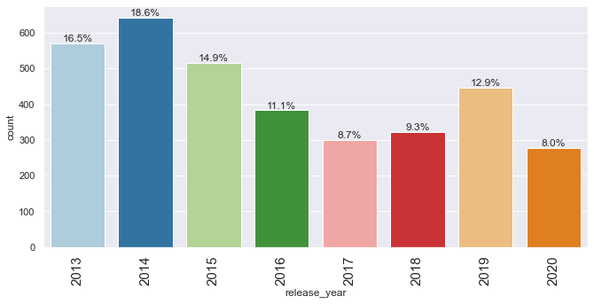

```python
labeled_barplot(df, "release_year", perc=True, n=10)
```

Observation: Barplot for release_year

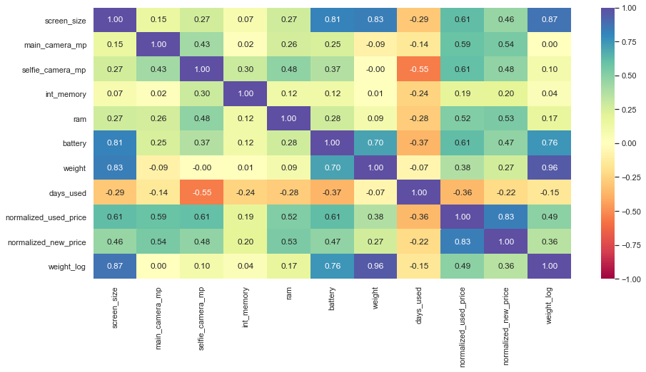

```python
cols_list = df.select_dtypes(include=np.number).columns.tolist()

cols_list.remove("release_year")

plt.figure(figsize=(15, 7))
sns.heatmap(
    df[cols_list].corr(), annot=True, vmin=-1, vmax=1, fmt=".2f", cmap="Spectral"
)
plt.show()
```

Observation: amount of RAM varies across brands.

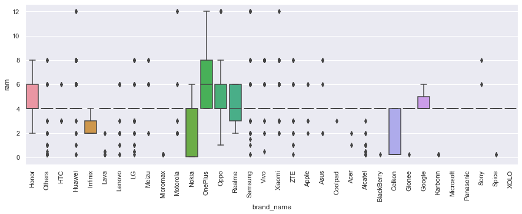

```python
plt.figure(figsize=(15, 5))
sns.boxplot(data=df, x="brand_name", y="ram")
plt.xticks(rotation=90)
plt.show()
```

Observation: dataframe of only those devices which offer a large battery and analyze.

```python
df_large_battery = df[df.battery > 4500]
df_large_battery.shape
```

```
(341, 16)
```

Observation: dataframe of only those devices which are suitable for such people and analyze.

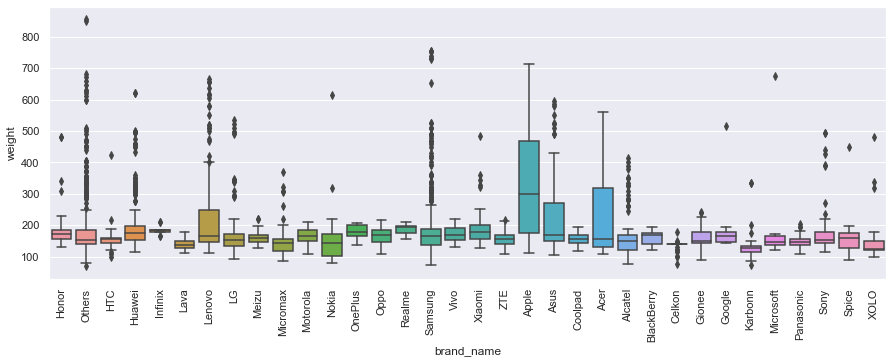

```python
plt.figure(figsize=(15, 5))
sns.boxplot(data=df, x="brand_name", y="weight")
plt.xticks(rotation=90)
plt.show()
```

```python
df_large_screen = df[df.screen_size > 6 * 2.54]
df_large_screen.shape
```

```
(1099, 16)
```

```python
labeled_barplot(df, "brand_name")
df_large_screen.brand_name.value_counts()
```

[output not shown]

```
Huawei       149
Samsung      119
Others        99
Vivo          80
Honor         72
Oppo          70
Xiaomi        69
Lenovo        69
LG            59
Motorola      42
Asus          41
Realme        40
Alcatel       26
Apple         24
Acer          19
Meizu         17
ZTE           17
OnePlus       16
Nokia         15
Sony          12
Infinix       10
HTC            7
Micromax       7
Google         4
Gionee         3
XOLO           3
Coolpad        3
Panasonic      2
Spice          2
Karbonn        2
Microsoft      1
Name: brand_name, dtype: int64
```

Observation: dataframe of only those devices which are suitable for this customer segment and analyze.

```python
df_selfie_camera = df[df.selfie_camera_mp > 8]
df_selfie_camera.shape
```

```
(655, 16)
```

```python
labeled_barplot(df, "brand_name")
df_selfie_camera.brand_name.value_counts()
```

[output not shown]

```
Huawei        87
Vivo          78
Oppo          75
Xiaomi        63
Samsung       57
Honor         41
Others        34
LG            32
Motorola      26
Meizu         24
HTC           20
ZTE           20
Realme        18
OnePlus       18
Sony          14
Lenovo        14
Nokia         10
Asus           6
Infinix        4
Gionee         4
Coolpad        3
Panasonic      2
Micromax       2
BlackBerry     2
Acer           1
Name: brand_name, dtype: int64
```

```python
df_main_camera = df[df.main_camera_mp > 16]
df_main_camera.shape
```

```
(94, 16)
```

```python
labeled_barplot(df, "brand_name")
df_main_camera.brand_name.value_counts()
```

[output not shown]

```
Sony          37
Motorola      11
Others         9
HTC            6
ZTE            5
Meizu          5
Microsoft      4
Nokia          4
Asus           3
BlackBerry     2
Samsung        2
Gionee         1
Lenovo         1
Panasonic      1
Honor          1
Xiaomi         1
Acer           1
Name: brand_name, dtype: int64
```

Observation: Rear cameras generally have a better resolution than front cameras, so we set the threshold higher for them at 16MP.

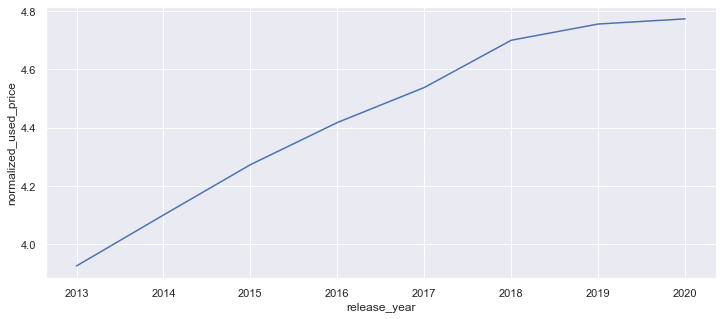

```python
plt.figure(figsize=(12, 5))
sns.lineplot(x="release_year", y="normalized_used_price", data=df, ci=None)
plt.show()
```

Observation: price of used devices varies across the years

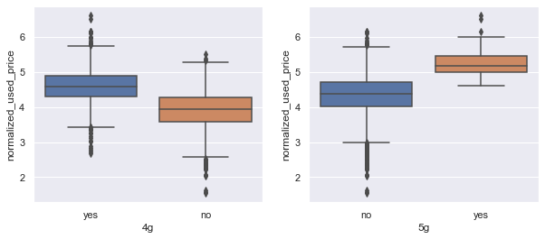

```python
plt.figure(figsize=(10, 4))

plt.subplot(121)
sns.boxplot(data=df, x="4g", y="normalized_used_price")

plt.subplot(122)
sns.boxplot(data=df, x="5g", y="normalized_used_price")

plt.show()
```

Observation: prices vary for used phones and tablets offering 4G and 5G networks.

```python
df1 = df.copy()
```

Observation: creating a copy of the data

```python
df1.isna().sum()
```

```
brand_name                 0
os                         0
screen_size                0
4g                         0
5g                         0
main_camera_mp           179
selfie_camera_mp           2
int_memory                 4
ram                        4
battery                    6
weight                     7
release_year               0
days_used                  0
normalized_used_price      0
normalized_new_price       0
weight_log                 7
dtype: int64
```

Observation: checking for missing values

```python
cols_impute = [
    "screen_size",
    "main_camera_mp",
    "selfie_camera_mp",
    "int_memory",
    "ram",
    "battery",
    "weight",
]

for col in cols_impute:
    df1[col] = df1.groupby(["release_year","brand_name"])[col].transform(
        lambda x: x.fillna(x.median())
    )
```

```python
cols_impute = [
    "main_camera_mp",
    "selfie_camera_mp",
    "battery",
    "weight",
]

for col in cols_impute:
    df1[col] = df1.groupby(["brand_name"])[col].transform(
        lambda x: x.fillna(x.median())
    )
```

Observation: impute the remaining missing values in the data by the column medians grouped by brand_name.

```python
df1["main_camera_mp"] = df1["main_camera_mp"].fillna(df1["main_camera_mp"].median(), inplace=True)


df1["weight_log"] = np.log(df1["weight"])


df1.isna().sum()
```

```
brand_name                  0
os                          0
screen_size                 0
4g                          0
5g                          0
main_camera_mp           3454
selfie_camera_mp            0
int_memory                  0
ram                         0
battery                     0
weight                      0
release_year                0
days_used                   0
normalized_used_price       0
normalized_new_price        0
weight_log                  0
dtype: int64
```

```python
df1["years_since_release"] = 2021 - df1["release_year"]
df1.drop("release_year", axis=1, inplace=True)
df1["years_since_release"].describe()
```

```
count    3454.000000
mean        5.034742
std         2.298455
min         1.000000
25%         3.000000
50%         5.500000
75%         7.000000
max         8.000000
Name: years_since_release, dtype: float64
```

Observation: Create a new column years_since_release from the release_year column. Drop the release_year column.

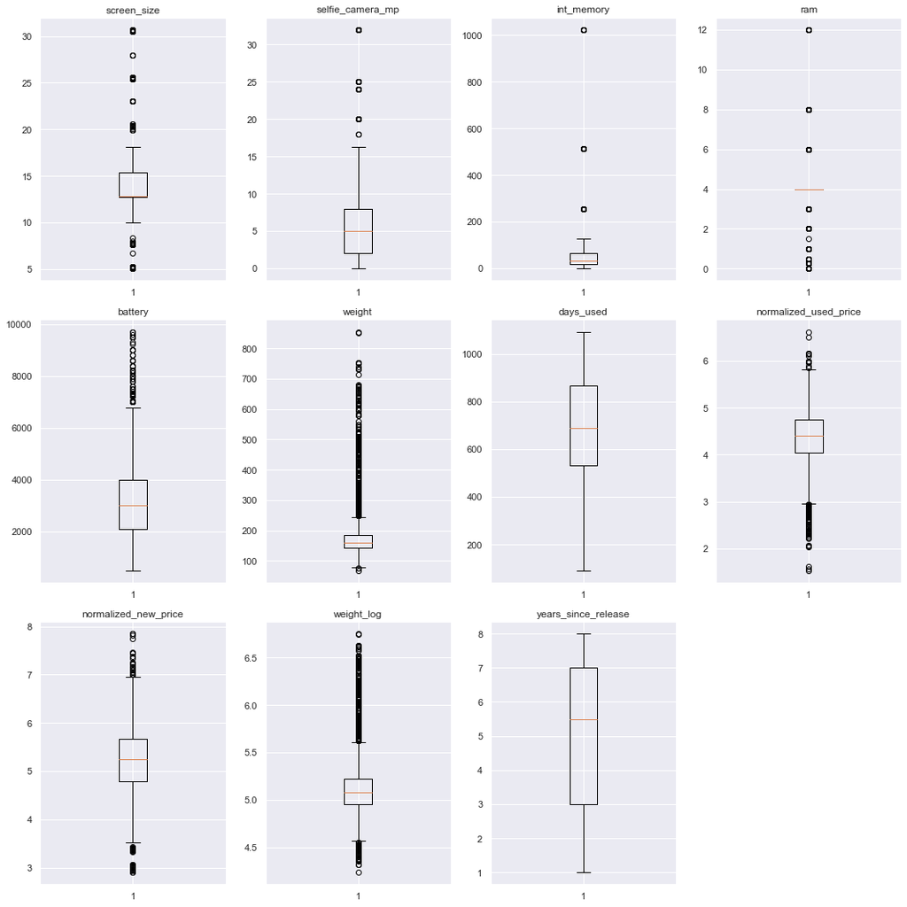

```python
numeric_columns = df1.select_dtypes(include=np.number).columns.tolist()

plt.figure(figsize=(15, 15))

for i, variable in enumerate(numeric_columns):
    plt.subplot(3, 4, i + 1)
    plt.boxplot(df1[variable], whis=1.5)
    plt.tight_layout()
    plt.title(variable)

plt.show()
```

Observation: Outlier detection using boxplot

```python
def treat_outliers(df, col):
    """
    Treats outliers in a variable

    df: dataframe
    col: dataframe column
    """
    Q1 = df[col].quantile(0.25)
    Q3 = df[col].quantile(0.75)
    IQR = Q3 - Q1
    Lower_Whisker = Q1 - 1.5 * IQR
    Upper_Whisker = Q3 + 1.5 * IQR


    df[col] = np.clip(df[col], Lower_Whisker, Upper_Whisker)

    return df


def treat_outliers_all(df, col_list):
    """
    Treat outliers in a list of variables

    df: dataframe
    col_list: list of dataframe columns
    """
    for c in col_list:
        df = treat_outliers(df, c)

    return df
```

Observation: functions to treat outliers by flooring and capping

```python
treat_out_cols = ["screen_size", "weight_log", "main_camera_mp", "selfie_camera_mp", "int_memory", "battery", "weight", "normalized_new_price", "normalized_used_price" ]

df2 = treat_outliers_all(df1, treat_out_cols)
```

Observation: specify the columns for which outliers have to be treated

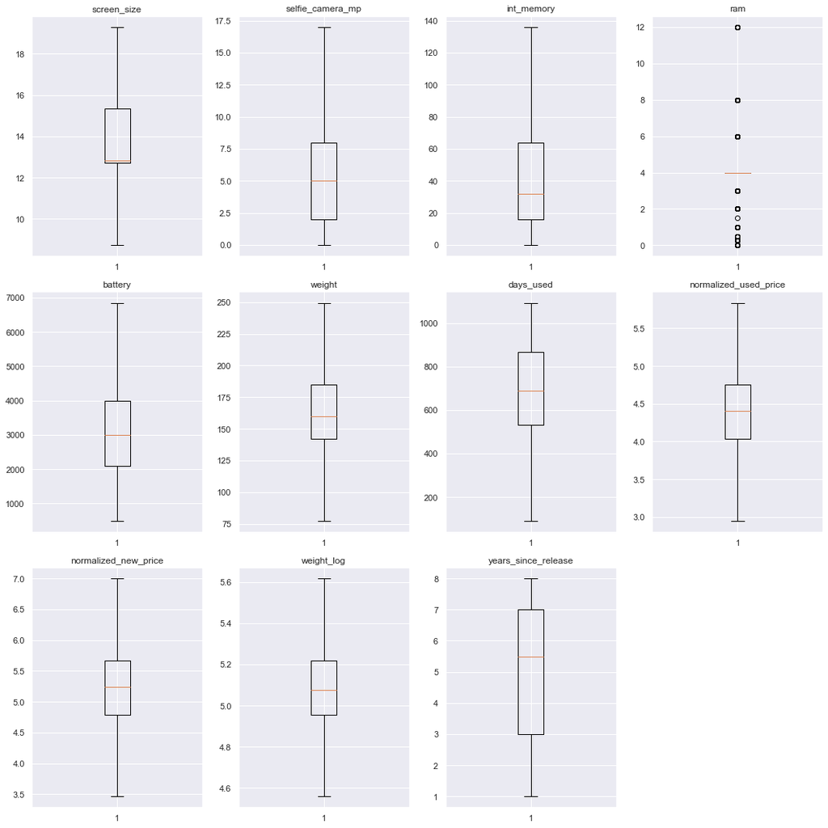

```python
plt.figure(figsize=(15, 15))

for i, variable in enumerate(numeric_columns):
    plt.subplot(3, 4, i + 1)
    plt.boxplot(df2[variable], whis=1.5)
    plt.tight_layout()
    plt.title(variable)

plt.show()
```

Observation: Recheck the boxplots to see if outliers were treated.

```python
df1.describe(include="all").T
```

|  | count | unique | top | freq | mean | std | min | 25% | 50% | 75% | max |
| --- | --- | --- | --- | --- | --- | --- | --- | --- | --- | --- | --- |
| brand_name | 3454 | 34 | Others | 502 | NaN | NaN | NaN | NaN | NaN | NaN | NaN |
| os | 3454 | 4 | Android | 3214 | NaN | NaN | NaN | NaN | NaN | NaN | NaN |
| screen_size | 3454.0 | NaN | NaN | NaN | 13.551595 | 2.807499 | 8.74 | 12.7 | 12.83 | 15.34 | 19.3 |
| 4g | 3454 | 2 | yes | 2335 | NaN | NaN | NaN | NaN | NaN | NaN | NaN |
| 5g | 3454 | 2 | no | 3302 | NaN | NaN | NaN | NaN | NaN | NaN | NaN |
| main_camera_mp | 0 | 0 | NaN | NaN | NaN | NaN | NaN | NaN | NaN | NaN | NaN |
| selfie_camera_mp | 3454.0 | NaN | NaN | NaN | 5.96242 | 5.345927 | 0.0 | 2.0 | 5.0 | 8.0 | 17.0 |
| int_memory | 3454.0 | NaN | NaN | NaN | 44.694079 | 39.079988 | 0.01 | 16.0 | 32.0 | 64.0 | 136.0 |
| ram | 3454.0 | NaN | NaN | NaN | 4.03262 | 1.368598 | 0.02 | 4.0 | 4.0 | 4.0 | 12.0 |
| battery | 3454.0 | NaN | NaN | NaN | 3109.100898 | 1212.793754 | 500.0 | 2100.0 | 3000.0 | 4000.0 | 6850.0 |
| weight | 3454.0 | NaN | NaN | NaN | 166.817371 | 38.857747 | 77.5 | 142.0 | 160.0 | 185.0 | 249.5 |
| days_used | 3454.0 | NaN | NaN | NaN | 674.869716 | 248.580166 | 91.0 | 533.5 | 690.5 | 868.75 | 1094.0 |
| normalized_used_price | 3454.0 | NaN | NaN | NaN | 4.371501 | 0.562947 | 2.951277 | 4.033931 | 4.405133 | 4.7557 | 5.838354 |
| normalized_new_price | 3454.0 | NaN | NaN | NaN | 5.234936 | 0.666538 | 3.465277 | 4.790342 | 5.245892 | 5.673718 | 6.998783 |
| weight_log | 3454.0 | NaN | NaN | NaN | 5.102005 | 0.244662 | 4.559034 | 4.955827 | 5.075174 | 5.220356 | 5.617149 |
| years_since_release | 3454.0 | NaN | NaN | NaN | 5.034742 | 2.298455 | 1.0 | 3.0 | 5.5 | 7.0 | 8.0 |

Observation: Check the statistical summary of the data once

```python
X = df1["normalized_used_price"]
y = df1["normalized_new_price"]

print(X.head())
print()
print(y.head())
```

```
0    4.307572
1    5.162097
2    5.111084
3    5.135387
4    4.389995
Name: normalized_used_price, dtype: float64

0    4.715100
1    5.519018
2    5.884631
3    5.630961
4    4.947837
Name: normalized_new_price, dtype: float64
```

Observation: Define the dependent and independent variables

```python
X = pd.get_dummies(
    X,
    columns=X.select_dtypes(include=["object", "category"]).columns.tolist(),
    drop_first=True,
)
X.head()
```

[output not shown]

Observation: Creating dummy variables

```python
x_train, x_test, y_train, y_test = train_test_split(X,y,test_size=0.3,random_state=1)
```

```python
print("Number of rows in train data =", x_train.shape[0])
print("Number of rows in test data =", x_test.shape[0])
```

```
Number of rows in train data = 2417
Number of rows in test data = 1037
```

Observation: Splitting the data in 70:30 ratio for train to test data

```python
x_train1 = sm.add_constant(x_train)

x_test1 = sm.add_constant(x_test)

olsmodel1 = sm.OLS(y_train,x_train1).fit()
print(olsmodel1.summary())
```

```
                             OLS Regression Results
================================================================================
Dep. Variable:     normalized_new_price   R-squared:                       0.684
Model:                              OLS   Adj. R-squared:                  0.684
Method:                   Least Squares   F-statistic:                     5227.
Date:                  Sat, 16 Apr 2022   Prob (F-statistic):               0.00
Time:                          22:17:35   Log-Likelihood:                -1040.4
No. Observations:                  2417   AIC:                             2085.
Df Residuals:                      2415   BIC:                             2096.
Df Model:                             1
Covariance Type:              nonrobust
=========================================================================================
                            coef    std err          t      P>|t|      [0.025      0.975]
-----------------------------------------------------------------------------------------
const                     0.9485      0.060     15.870      0.000       0.831       1.066
normalized_used_price     0.9799      0.014     72.299      0.000       0.953       1.006
==============================================================================
Omnibus:                       97.230   Durbin-Watson:                   1.987
Prob(Omnibus):                  0.000   Jarque-Bera (JB):              109.330
Skew:                           0.489   Prob(JB):                     1.82e-24
Kurtosis:                       3.358   Cond. No.                         36.6
==============================================================================

Notes:
[1] Standard Errors assume that the covariance matrix of the errors is correctly specified.
```

Observation: Build a linear regression model using statsmodels.

```python
def adj_r2_score(predictors, targets, predictions):
    r2 = r2_score(targets, predictions)
    n = predictors.shape[0]
    k = predictors.shape[1]
    return 1 - ((1 - r2) * (n - 1) / (n - k - 1))



def mape_score(targets, predictions):
    return np.mean(np.abs(targets - predictions) / targets) * 100



def model_performance_regression(model, predictors, target):
    """
    Function to compute different metrics to check regression model performance

    model: regressor
    predictors: independent variables
    target: dependent variable
    """


    pred = model.predict(predictors)

    r2 = r2_score(target, pred)
    adjr2 = adj_r2_score(predictors, target, pred)
    rmse = np.sqrt(mean_squared_error(target, pred))
    mae = mean_absolute_error(target, pred)
    mape = mape_score(target, pred)


    df_perf = pd.DataFrame(
        {
            "RMSE": rmse,
            "MAE": mae,
            "R-squared": r2,
            "Adj. R-squared": adjr2,
            "MAPE": mape,
        },
        index=[0],
    )

    return df_perf
```

Observation: Using metric functions defined in sklearn for RMSE, MAE, and R2. Define a function to calculate MAPE and adjusted R2. Create a function which will print out all the above metrics in one go.

```python
print("Training Performance\n")
olsmodel1_train_perf = model_performance_regression(olsmodel1, x_train1, y_train)
olsmodel1_train_perf
```

```
Training Performance
```

|  | RMSE | MAE | R-squared | Adj. R-squared | MAPE |
| --- | --- | --- | --- | --- | --- |
| 0 | 0.372138 | 0.29562 | 0.683987 | 0.683725 | 5.703007 |

Observation: Checking model performance on train set (seen 70% data)

```python
print("Test Performance\n")
olsmodel1_test_perf = model_performance_regression(olsmodel1,x_test1,y_test)
olsmodel1_test_perf
```

```
Test Performance
```

|  | RMSE | MAE | R-squared | Adj. R-squared | MAPE |
| --- | --- | --- | --- | --- | --- |
| 0 | 0.377066 | 0.293489 | 0.689517 | 0.688916 | 5.691071 |

Observation: Checking model performance on test set (seen 30% data)

```python
from statsmodels.stats.outliers_influence import variance_inflation_factor


def checking_vif(predictors):
    vif = pd.DataFrame()
    vif["feature"] = predictors.columns


    vif["VIF"] = [
        variance_inflation_factor(predictors.values, i)
        for i in range(len(predictors.columns))
    ]
    return vif
```

Observation: Define a function to check VIF

```python
checking_vif(x_train1)
```

|  | feature | VIF |
| --- | --- | --- |
| 0 | const | 62.283614 |
| 1 | normalized_used_price | 1.000000 |

Observation: To check VIF on train data

```python
def treating_multicollinearity(predictors, target, high_vif_columns):
    """
    Checking the effect of dropping the columns showing high multicollinearity
    on model performance (adj. R-squared and RMSE)

    predictors: independent variables
    target: dependent variable
    high_vif_columns: columns having high VIF
    """

    adj_r2 = []
    rmse = []


    for cols in high_vif_columns:

        train = predictors.loc[:, ~predictors.columns.str.startswith(cols)]


        olsmodel = sm.OLS(target, train).fit()


        adj_r2.append(olsmodel.rsquared_adj)
        rmse.append(np.sqrt(olsmodel.mse_resid))


    temp = pd.DataFrame(
        {
            "col": high_vif_columns,
            "Adj. R-squared after_dropping col": adj_r2,
            "RMSE after dropping col": rmse,
        }
    ).sort_values(by="Adj. R-squared after_dropping col", ascending=False)
    temp.reset_index(drop=True, inplace=True)

    return temp
```

Observation: To remove multicollinearity

```python
col_list = []

res = treating_multicollinearity(x_test, y_train, col_list)
res
```

|  | col | Adj. R-squared after_dropping col | RMSE after dropping col |
| --- | --- | --- | --- |

Observation: specify the columns with high VIF

```python
col_to_drop = "normalized_used_price"
X_train2 = X_train.loc[:, ~X_train.columns.str.startswith(col_to_drop)]
X_test2 = X_test.loc[:, ~X_test.columns.str.startswith(col_to_drop)]


vif = checking_vif(X_train2)
print("VIF after dropping ", col_to_drop)
vif
```

[output not shown]

Observation: specify the column to drop, the train data from which to drop the column specified, the test data from which to drop the column specified

```python
cols = x_train1.columns.tolist()


max_p_value = 1

while len(cols) > 0:

    x_train_aux = x_train1[cols]


    model = sm.OLS(y_train, x_train_aux).fit()


    p_values = model.pvalues
    max_p_value = max(p_values)


    feature_with_p_max = p_values.idxmax()

    if max_p_value > 0.05:
        cols.remove(feature_with_p_max)
    else:
        break

selected_features = cols
print(selected_features)
```

```
['const', 'normalized_used_price']
```

Observation: Dropping high p-value variables (if needed)

```python
x_train2 = x_train1[selected_features]
x_test2 = x_test1[selected_features]
```

```python
olsmodel2 = sm.OLS(y_train,x_train2).fit()
print(olsmodel2.summary())
```

```
                             OLS Regression Results
================================================================================
Dep. Variable:     normalized_new_price   R-squared:                       0.684
Model:                              OLS   Adj. R-squared:                  0.684
Method:                   Least Squares   F-statistic:                     5227.
Date:                  Sat, 16 Apr 2022   Prob (F-statistic):               0.00
Time:                          22:25:39   Log-Likelihood:                -1040.4
No. Observations:                  2417   AIC:                             2085.
Df Residuals:                      2415   BIC:                             2096.
Df Model:                             1
Covariance Type:              nonrobust
=========================================================================================
                            coef    std err          t      P>|t|      [0.025      0.975]
-----------------------------------------------------------------------------------------
const                     0.9485      0.060     15.870      0.000       0.831       1.066
normalized_used_price     0.9799      0.014     72.299      0.000       0.953       1.006
==============================================================================
Omnibus:                       97.230   Durbin-Watson:                   1.987
Prob(Omnibus):                  0.000   Jarque-Bera (JB):              109.330
Skew:                           0.489   Prob(JB):                     1.82e-24
Kurtosis:                       3.358   Cond. No.                         36.6
==============================================================================

Notes:
[1] Standard Errors assume that the covariance matrix of the errors is correctly specified.
```

Observation: fit OLS() on updated dataset (no multicollinearity and no insignificant predictors)

```python
print("Training Performance\n")
olsmodel1_train_perf = model_performance_regression(olsmodel1,x_train1,y_train)
olsmodel1_train_perf
```

```
Training Performance
```

|  | RMSE | MAE | R-squared | Adj. R-squared | MAPE |
| --- | --- | --- | --- | --- | --- |
| 0 | 0.372138 | 0.29562 | 0.683987 | 0.683725 | 5.703007 |

Observation: model performance on train set (seen 70% data)

```python
print("Test Performance\n")
olsmodel1_test_perf = model_performance_regression(olsmodel1,x_test1,y_test)
olsmodel1_test_perf
```

```
Test Performance
```

|  | RMSE | MAE | R-squared | Adj. R-squared | MAPE |
| --- | --- | --- | --- | --- | --- |
| 0 | 0.377066 | 0.293489 | 0.689517 | 0.688916 | 5.691071 |

```python
Observation: model performance on test set (seen 30% data)
```

```python
df_pred = pd.DataFrame()

df_pred["Actual Values"] = y_train
df_pred["Fitted Values"] = olsmodel2.fittedvalues
df_pred["Residuals"] = olsmodel2.resid

df_pred.head()
```

|  | Actual Values | Fitted Values | Residuals |
| --- | --- | --- | --- |
| 3026 | 4.796204 | 4.953648 | -0.157445 |
| 1525 | 5.434595 | 5.307293 | 0.127302 |
| 1128 | 5.137914 | 5.176925 | -0.039011 |
| 3003 | 5.189228 | 5.144311 | 0.044917 |
| 2907 | 5.016220 | 5.315170 | -0.298950 |

Observation: create a dataframe with actual, fitted and residual values

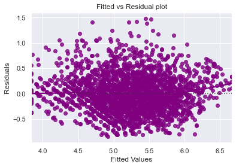

```python
sns.residplot(
    data=df_pred, x="Fitted Values", y="Residuals", color="purple", lowess=True
)
plt.xlabel("Fitted Values")
plt.ylabel("Residuals")
plt.title("Fitted vs Residual plot")
plt.show()
```

Observation: plot the fitted values vs residuals

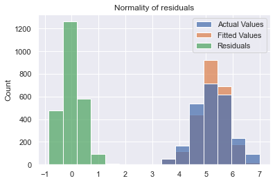

```python
sns.histplot(data=df_pred, bins="auto")
plt.title("Normality of residuals")
plt.show()
```

Observation: to plot the distribution of residuals

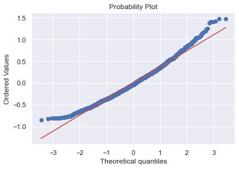

```python
import pylab
import scipy.stats as stats

stats.probplot(df_pred["Residuals"] ,dist="norm", plot=pylab)
plt.show()
```

Observation: check Q-Q plot

```python
stats.shapiro(df_pred["Residuals"])
```

```
ShapiroResult(statistic=0.9859669804573059, pvalue=1.0638639796856867e-14)
```

Observation: apply the Shapiro-Wilks test

```python
import statsmodels.stats.api as sms
from statsmodels.compat import lzip

name = ["F statistic", "p-value"]
test = sms.het_goldfeldquandt(df_pred.Residuals,olsmodel2.model.exog)
lzip(name, test)
```

```
[('F statistic', 0.9553661644127769), ('p-value', 0.7860512089113483)]
```

Observation: to apply the Goldfeldquandt test

```python
olsmodel_final = sm.OLS(y_train,x_train2).fit()
print(olsmodel_final.summary())
```

```
                             OLS Regression Results
================================================================================
Dep. Variable:     normalized_new_price   R-squared:                       0.684
Model:                              OLS   Adj. R-squared:                  0.684
Method:                   Least Squares   F-statistic:                     5227.
Date:                  Sat, 16 Apr 2022   Prob (F-statistic):               0.00
Time:                          22:38:12   Log-Likelihood:                -1040.4
No. Observations:                  2417   AIC:                             2085.
Df Residuals:                      2415   BIC:                             2096.
Df Model:                             1
Covariance Type:              nonrobust
=========================================================================================
                            coef    std err          t      P>|t|      [0.025      0.975]
-----------------------------------------------------------------------------------------
const                     0.9485      0.060     15.870      0.000       0.831       1.066
normalized_used_price     0.9799      0.014     72.299      0.000       0.953       1.006
==============================================================================
Omnibus:                       97.230   Durbin-Watson:                   1.987
Prob(Omnibus):                  0.000   Jarque-Bera (JB):              109.330
Skew:                           0.489   Prob(JB):                     1.82e-24
Kurtosis:                       3.358   Cond. No.                         36.6
==============================================================================

Notes:
[1] Standard Errors assume that the covariance matrix of the errors is correctly specified.
```

Observation: to fit the final model

```python
print("Training Performance\n")
olsmodel_final_train_perf = model_performance_regression(olsmodel_final,x_train2,y_train)
olsmodel_final_train_perf
```

```
Training Performance
```

|  | RMSE | MAE | R-squared | Adj. R-squared | MAPE |
| --- | --- | --- | --- | --- | --- |
| 0 | 0.372138 | 0.29562 | 0.683987 | 0.683725 | 5.703007 |

```python
Observation: model performance on train set (seen 70% data), check the performance on train data
```

```python
print("Test Performance\n")
olsmodel_final_test_perf = model_performance_regression(olsmodel_final,x_test2,y_test)
olsmodel_final_test_perf
```

```
Test Performance
```

|  | RMSE | MAE | R-squared | Adj. R-squared | MAPE |
| --- | --- | --- | --- | --- | --- |
| 0 | 0.377066 | 0.293489 | 0.689517 | 0.688916 | 5.691071 |

```python
Observation: model performance on test set (seen 30% data), to check performance on test data
```